# 7-enrichment-analysis.RMD

Ana BVA

2 February 2021

## Introduction

We previously had run the following scripts:

- 0: Data selection `/0-Data-selection.RMD`
- 1: Dowload RAW data `/1-download_raw-data.RMD`
- 2: Normalizing data `/2-normalizing-data.RMD`
- 3: Curating data `/3-curatig-data.RMD`
- 4: Differential gene expression analysis `/4-DE.RMD`
- 5: Merging data `/5-merge-data.RMD`
- 6: Merging data `/6-meta-analysis.RMD`

## Input

This script needs the following files:

**Data:** Meta-analysis results in `csv` files

## Analysis

### Setup

For running the script, type:

```bash
ssh -X aaltamirano@dna.lavis.unam.mx
qrsh
cd /mnt/Genoma/amedina/DataDNA/R-projects/Meta-analysis_COPD/output_data/.out
 module load r/4.0.1

## OR
ssh ana@10.200.0.42
cd /home/ana/DataDNA/R-projects/Meta-analysis_COPD/output_data/.out

nohup R -e "rmarkdown::render(here::here('vignettes/8-enrichment-pathways.RMD'))" > 8-enrichment-pathways.RMD.out &
```

The script can be found in: /Users/user/Documents/Doctorado/Analysis/Meta-analysis_COPD/Tissue/vignettes. And the directories were set using `R/setup.R` (e.i. DATA, OUPUT, DOWNLOAD) as a small functions that will paste the names into complete paths.

```r
knitr::opts_knit$set(root.dir = here::here())
source(here::here("Tissue/R/setup.R"))
```

And this analysis is run in: /Users/user/Documents/Doctorado/Analysis/Meta-analysis_COPD

### Libraries

```r
library(hypeR)
library(WGCNA)
library(tidyverse)
library(reactable)
library(ggpubr)
```

### Import data

We will import DE results from all experiments.

```r
meta <- read_csv(OUTPUT("2021-02-02_Step6_meta-analysis.csv"))
meta
```

```
## # A tibble: 24,127 x 9
##    X1     TE.fixed pval.fixed  tau2    I2    pval.Q num_exp qval.fixed    qval.Q
##    <chr>     <dbl>      <dbl> <dbl> <dbl>     <dbl>   <dbl>      <dbl>     <dbl>
##  1 IL1R2   -0.387    1.24e-10 2.31  0.984 2.45e-131      11   1.25e- 8 5.91e-127
##  2 SLCO4…  -0.882    2.53e-36 1.46  0.981 9.98e- 95      10   3.06e-32 8.03e- 91
##  3 FKBP5   -0.261    1.50e- 7 1.10  0.981 1.88e-109      11   4.90e- 6 2.27e-105
##  4 SH3PX…  -0.0908   2.62e- 2 0.415 0.979 1.05e- 78       9   8.69e- 2 5.08e- 75
##  5 GALNT…  -0.756    1.54e-28 0.819 0.980 1.66e- 41       5   6.20e-25 1.08e- 38
##  6 IRAK3   -0.250    4.03e-10 0.393 0.972 3.64e- 58       9   3.36e- 8 8.77e- 55
##  7 TIMP4   -0.0931   3.55e- 2 0.555 0.969 2.42e- 64      11   1.09e- 1 7.30e- 61
##  8 CEACA…  -0.0948   2.72e- 3 0.373 0.968 9.96e- 56      10   1.51e- 2 1.85e- 52
##  9 SULT1…  -0.0438   1.88e- 1 0.585 0.969 2.41e- 56      10   3.60e- 1 5.29e- 53
## 10 ITGA10  -0.424    1.85e-22 0.257 0.955 2.00e- 34       9   6.37e-19 7.54e- 32
## # … with 24,117 more rows
```

### Ranking and weighted values

```r
qval_cutoff <- 0.05

up_df <- meta %>%
  filter(qval.fixed <= qval_cutoff) %>%
  filter(is.na(tau2) == F) %>%
  #filter(TE.fixed > 0) %>%
  dplyr::arrange(desc(TE.fixed))
  #dplyr::arrange(estimate)

up_signature <- as.vector(up_df$TE.fixed)
names(up_signature) <- up_df$X1
head(up_signature)
```

```
##       FGG    FAM38B      FOSB       IGJ  MGC29506     RN7SK
## 1.1769505 0.9570875 0.7775483 0.7646391 0.7585784 0.6602695
```

```r
down_df <- meta %>%
  filter(qval.fixed <= qval_cutoff) %>%
  filter(is.na(tau2) == F) %>%
  #filter(TE.fixed < 0) %>%
  dplyr::arrange((TE.fixed))
  #dplyr::arrange(estimate)

down_signature <- as.vector(down_df$TE.fixed)
names(down_signature) <- down_df$X1
head(down_signature)
```

```
##    AADACL3    SNORA70    SLCO4A1    PPIAL4G     SPRR2F      PRINS
## -1.0093902 -0.9581023 -0.8817848 -0.8678261 -0.7912242 -0.7837010
```

### Enrichment analysis

```r
# KEGG
KEGG <- hyperdb_rgsets("KEGG", "92.0")

#HALLMARL
HALLMARK <- msigdb_gsets(species="Homo sapiens", category="H",clean = T)

#ENRICHR
TF_TJ <- enrichr_gsets("TRANSFAC_and_JASPAR_PWMs")

enrichR<- enrichr_gsets("Jensen_DISEASES")

enrichR<- enrichr_gsets("Jensen_TISSUES")

enrichR<- enrichr_gsets("Chromosome_Location")

enrichR<- enrichr_gsets("WikiPathways_2019_Human")

enrichR<- enrichr_gsets("ClinVar_2019")
```

```r
# KEGG
KEGG <- hyperdb_rgsets("KEGG", "92.0")

#HALLMARL
HALLMARK <- msigdb_gsets(species="Homo sapiens", category="H",clean = T)
```

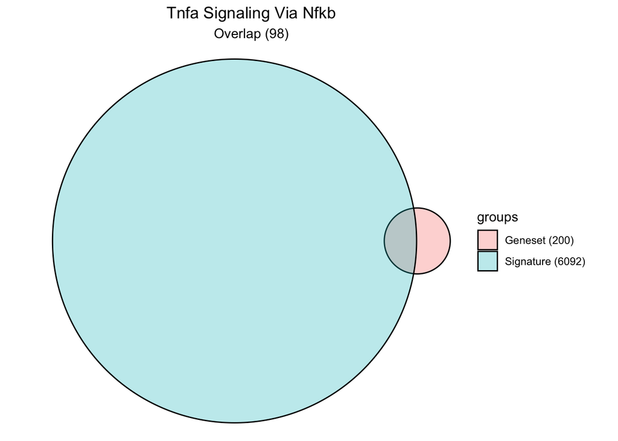

```r
DB <- KEGG
DB <- HALLMARK
  # Ranked Signature using the estimator from the meta analysis (FC)
  hyp_obj <- hypeR(names(up_signature),DB, test="hypergeometric", background=nrow(meta), fdr=0.5, plotting=TRUE)
  hyp_obj$plots[[1]]
```

```r
  hyp_obj
```

```
## (hyp)
##
##   data:
##                    label    pval     fdr signature geneset overlap background
##  Tnfa Signaling Via Nfkb 3.5e-13 1.8e-11      6092     200      98      24127
##    Inflammatory Response 9.4e-10 2.4e-08      6092     200      90      24127
##                Apoptosis 3.6e-09 5.9e-08      6092     161      75      24127
##        Kras Signaling Up 6.9e-08 8.6e-07      6092     200      85      24127
##  Il6 Jak Stat3 Signaling 1.1e-07 1.1e-06      6092      87      45      24127
##      Allograft Rejection 1.5e-07 1.1e-06      6092     200      84      24127
##                                                                                                                                                                                                                                                                                                          …
##  ATF3,ATP2B1,B4GALT1,BCL2A1,BCL6,BHLHE40,BIRC3,BMP2,BTG1,BTG2,CCL2,CCNL1,CD44,CD69,CD83,CDKN1A,CSF1,CSF2,CXCL1,CXCL2,CXCL3,DNAJB4,DRAM1,DUSP2,DUSP5,EDN1,EFNA1,EGR1,EGR2,EGR3,FOSB,FOSL2,G0S2,GADD45A,GADD45B,GEM,GPR183,HBEGF,ICAM1,IER2,IER3,IL1B,IL6,INHBA,IRF1,IRS2,JUN,JUNB,KDM6B,KYNU,LIF,LITAF,MAF…
##                                                     ADORA2B,ADRM1,AHR,APLNR,ATP2A2,ATP2B1,AXL,BDKRB1,BST2,BTG2,CCL2,CCL22,CCL24,CCR7,CD48,CD69,CD70,CD82,CDKN1A,CLEC5A,CSF1,CSF3,CYBB,DCBLD2,EDN1,FFAR2,GABBR1,GPC3,GPR132,GPR183,HAS2,HBEGF,HIF1A,HPN,HRH1,ICAM1,ICAM4,IFITM1,IFNAR1,IL18R1,IL18RAP,IL1B…
##                                                                                                                                            ANKH,APP,ATF3,AVPR1A,BCAP31,BCL10,BCL2L11,BCL2L2,BIRC3,BMP2,BNIP3L,BTG2,CASP6,CASP8,CAV1,CCND2,CD44,CD69,CDC25B,CDKN1A,CREBBP,CTNNB1,CYLD,DDIT3,DFFA,DIABLO,DN…
##                                                          ACE,ALDH1A2,ALDH1A3,ANKH,ANO1,AVL9,BIRC3,BMP2,BTBD3,CAB39L,CBL,CCND2,CCSER2,CFB,CLEC4A,CPE,CSF2,CSF2RA,CTSS,DCBLD2,DOCK2,EMP1,EPHB2,ETV1,F13A1,FLT4,FUCA1,G0S2,GADD45G,GLRX,GNG11,GPNMB,GPRC5B,HBEGF,HDAC9,IGFBP3,IKZF1,IL1B,IL2RG,INHBA,ITGA2,I…
##                                                                                                                                                                                                                                                                                                          …
##                                                                                      ACHE,APBB1,BCAT1,BCL10,CARTPT,CCL11,CCL13,CCL19,CCL2,CCL22,CCND2,CCND3,CCR1,CD1D,CD28,CD4,CD79A,CD86,CD8B,CD96,CDKN2A,CSF1,CTSS,CXCL13,DYRK3,EIF3J,EIF4G3,FAS,FASLG,FCGR2B,FGR,GALNT1,GCNT1,GPR65,HDAC9,HIF1A,HLA-A,…
##
##   plots: 43 Figures
##
##   args: signature
##         genesets
##         test
##         background
##         power
##         absolute
##         pval
##         fdr
##         plotting
##         quiet
```

```r
  hyp_dots(hyp_obj) + theme_minimal()
```

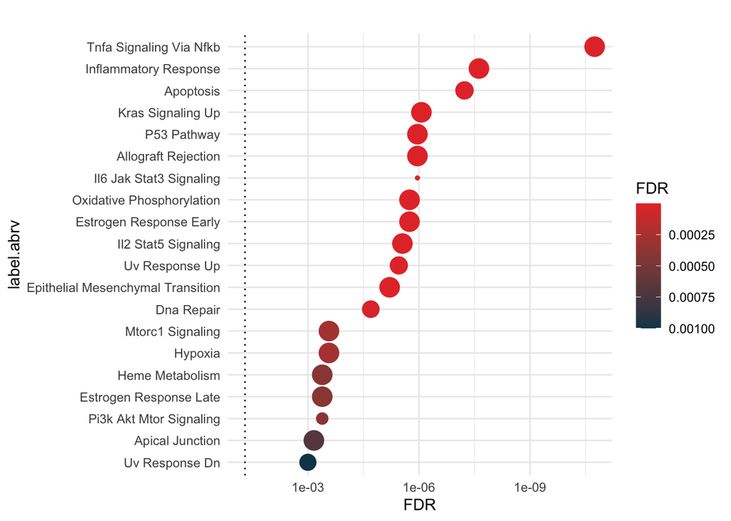

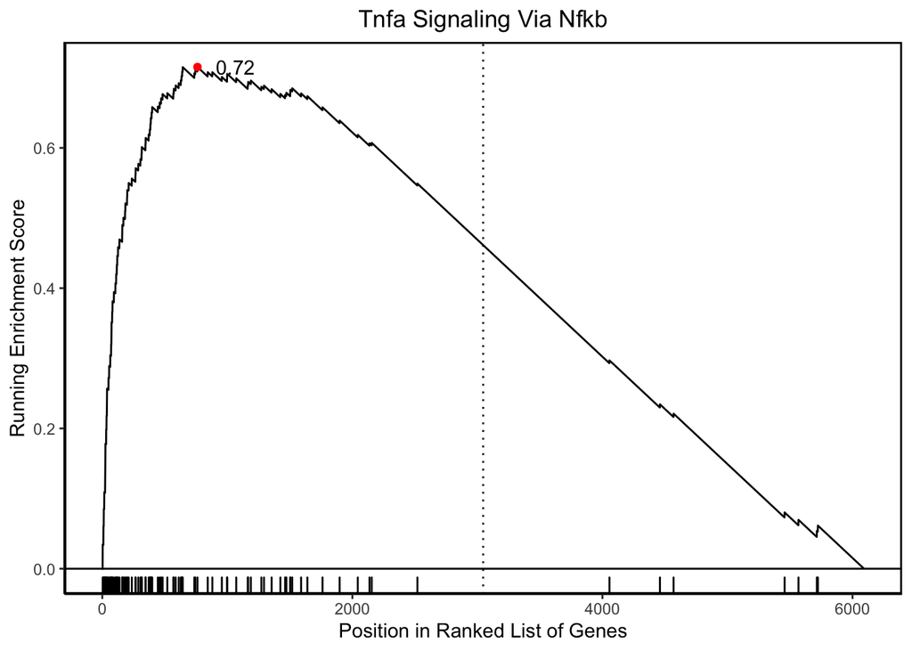

```r
  # Weighted Signature using as ranking the estimator and the weighted the qvalue
  hyp_obj <- hypeR(up_signature, DB, test="kstest", background=nrow(meta),fdr=0.5, plotting=TRUE)
  hyp_obj$plots[[1]]
```

```r
  hyp_dots(hyp_obj) + theme_minimal(14)
```

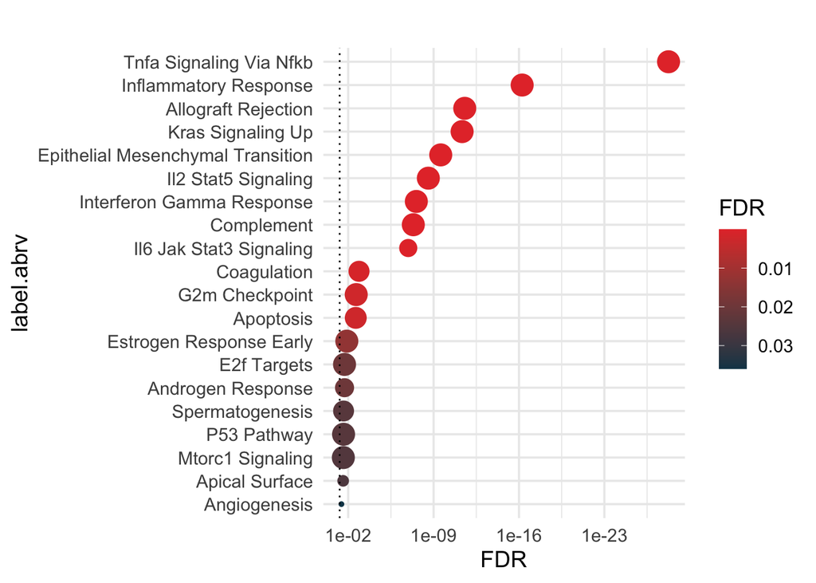

```r
  # Show interactive table
  #hyp_show(hyp_obj)

  # Plot enrichment map
  #hyp_emap(hyp_obj)

  # Plot hiearchy map
  #hyp_hmap(hyp_obj)

  # Generate markdown report
  #hyp_to_rmd(hyp_obj,"hypr-KEGG-genesets.rmd")
  #hyp_to_rmd(hyp_obj,"hypr-TRANSFAC_and_JASPAR_PWMs.rmd")
```

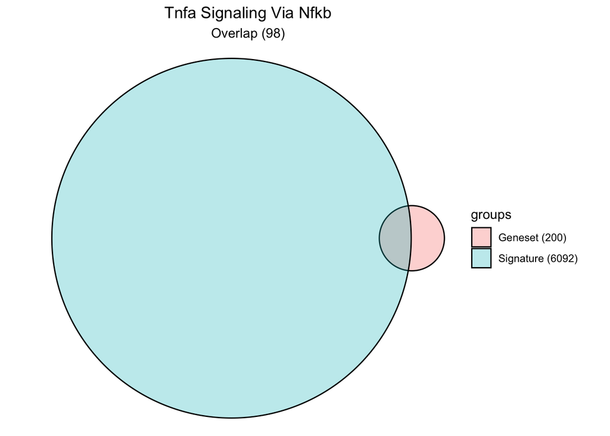

```r
  # Ranked Signature using the estimator from the meta analysis (FC)
  hyp_obj <- hypeR(names(down_signature),DB, test="hypergeometric", background=nrow(meta), fdr=0.5, plotting=TRUE)
  hyp_obj$plots[[1]]
```

```r
  hyp_obj
```

```
## (hyp)
##
##   data:
##                    label    pval     fdr signature geneset overlap background
##  Tnfa Signaling Via Nfkb 3.5e-13 1.8e-11      6092     200      98      24127
##    Inflammatory Response 9.4e-10 2.4e-08      6092     200      90      24127
##                Apoptosis 3.6e-09 5.9e-08      6092     161      75      24127
##        Kras Signaling Up 6.9e-08 8.6e-07      6092     200      85      24127
##  Il6 Jak Stat3 Signaling 1.1e-07 1.1e-06      6092      87      45      24127
##      Allograft Rejection 1.5e-07 1.1e-06      6092     200      84      24127
##                                                                                                                                                                                                                                                                                                          …
##  ATF3,ATP2B1,B4GALT1,BCL2A1,BCL6,BHLHE40,BIRC3,BMP2,BTG1,BTG2,CCL2,CCNL1,CD44,CD69,CD83,CDKN1A,CSF1,CSF2,CXCL1,CXCL2,CXCL3,DNAJB4,DRAM1,DUSP2,DUSP5,EDN1,EFNA1,EGR1,EGR2,EGR3,FOSB,FOSL2,G0S2,GADD45A,GADD45B,GEM,GPR183,HBEGF,ICAM1,IER2,IER3,IL1B,IL6,INHBA,IRF1,IRS2,JUN,JUNB,KDM6B,KYNU,LIF,LITAF,MAF…
##                                                     ADORA2B,ADRM1,AHR,APLNR,ATP2A2,ATP2B1,AXL,BDKRB1,BST2,BTG2,CCL2,CCL22,CCL24,CCR7,CD48,CD69,CD70,CD82,CDKN1A,CLEC5A,CSF1,CSF3,CYBB,DCBLD2,EDN1,FFAR2,GABBR1,GPC3,GPR132,GPR183,HAS2,HBEGF,HIF1A,HPN,HRH1,ICAM1,ICAM4,IFITM1,IFNAR1,IL18R1,IL18RAP,IL1B…
##                                                                                                                                            ANKH,APP,ATF3,AVPR1A,BCAP31,BCL10,BCL2L11,BCL2L2,BIRC3,BMP2,BNIP3L,BTG2,CASP6,CASP8,CAV1,CCND2,CD44,CD69,CDC25B,CDKN1A,CREBBP,CTNNB1,CYLD,DDIT3,DFFA,DIABLO,DN…
##                                                          ACE,ALDH1A2,ALDH1A3,ANKH,ANO1,AVL9,BIRC3,BMP2,BTBD3,CAB39L,CBL,CCND2,CCSER2,CFB,CLEC4A,CPE,CSF2,CSF2RA,CTSS,DCBLD2,DOCK2,EMP1,EPHB2,ETV1,F13A1,FLT4,FUCA1,G0S2,GADD45G,GLRX,GNG11,GPNMB,GPRC5B,HBEGF,HDAC9,IGFBP3,IKZF1,IL1B,IL2RG,INHBA,ITGA2,I…
##                                                                                                                                                                                                                                                                                                          …
##                                                                                      ACHE,APBB1,BCAT1,BCL10,CARTPT,CCL11,CCL13,CCL19,CCL2,CCL22,CCND2,CCND3,CCR1,CD1D,CD28,CD4,CD79A,CD86,CD8B,CD96,CDKN2A,CSF1,CTSS,CXCL13,DYRK3,EIF3J,EIF4G3,FAS,FASLG,FCGR2B,FGR,GALNT1,GCNT1,GPR65,HDAC9,HIF1A,HLA-A,…
##
##   plots: 43 Figures
##
##   args: signature
##         genesets
##         test
##         background
##         power
##         absolute
##         pval
##         fdr
##         plotting
##         quiet
```

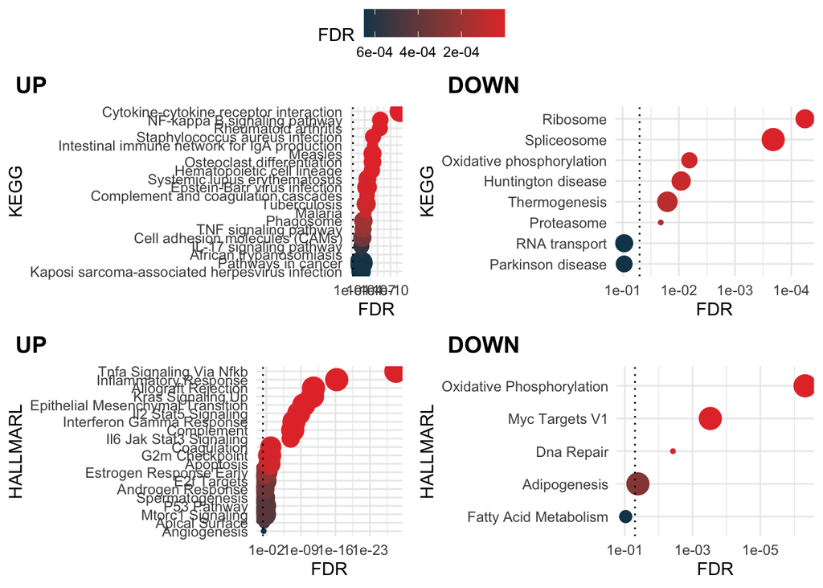

```r
# UP KEGG
up_kegg_obj <- hypeR(up_signature,
                   KEGG,
                   test="kstest",
                   background=nrow(meta),
                   fdr=0.1, plotting=TRUE)

 up_kegg <-  hyp_dots(up_kegg_obj) + theme_minimal() + xlab("KEGG")

 # UP HALLMARL
 up_hall_obj <- hypeR(up_signature,
                   HALLMARK,
                   test="kstest",
                   background=nrow(meta),
                   fdr=0.1, plotting=TRUE)

 up_hall <-  hyp_dots(up_hall_obj) + theme_minimal() + xlab("HALLMARL")

 # UP KEGG
down_kegg_obj <- hypeR(down_signature,
                   KEGG,
                   test="kstest",
                   background=nrow(meta),
                   fdr=0.1, plotting=TRUE)

 down_kegg <-  hyp_dots(down_kegg_obj) + theme_minimal() + xlab("KEGG")


  # DOWN HALLMARL
 down_hall_obj <- hypeR(down_signature,
                   HALLMARK,
                   test="kstest",
                   background=nrow(meta),
                   fdr=0.1, plotting=TRUE)

 down_hall <-  hyp_dots(down_hall_obj) + theme_minimal() + xlab("HALLMARL")


ggpubr::ggarrange(up_kegg,down_kegg,up_hall,down_hall,
                   common.legend = T,
                   labels = c("UP","DOWN","UP","DOWN"),
                   ncol = 2,nrow = 2)
```

## Output

This script produces the following data, and can be found in /Users/user/Documents/Doctorado/Analysis/Meta-analysis_COPD

**Figures in the vignette:** Enrichment analysis with plots